# Cloud Spend Forecasting with Monte Carlo Simulaton

#### Using FinOps FOCUS Data and Python’s PyMC to Create Probabilistic Budget Forecasts

## Intro

This project demonstrates a simple approach to generate probabilistic budget forcasts using Python's PyMC package. By simulating a range of possible outcomes, Monte Carlo techniques enable Finance teams to consider uncertainty and variability in financial forecasts, providing more robust insights than the fixed-point estimates used in traditional budgeting.

Additionally, the project leverages the FOCUS dataset, a new standardized format for FinOps cloud spend data. Tracking and managing cloud computing costs has become critical as rapid growth in cloud services threaten to cause unallocated spending and budget overruns.

```python
import pandas as pd
import numpy as np
import matplotlib.pyplot as plt
import pymc as pm
import arviz as az
import xarray as xr
```

```python
import warnings
warnings.filterwarnings('ignore')
```

## Data Sources

### 1. FinOps FOCUS Report

For actual year-to-date cloud spend data, we will use a sample FOCUS report provided my Microsoft's FinOps toolkit here:

https://microsoft.github.io/finops-toolkit/data#%EF%B8%8F-dataset-examples

The FOCUS report is a unified template for analyzing cloud spend data from any service provider. You can learn more about the FOCUS report here:

https://focus.finops.org/what-is-focus/

```python
focus_df = pd.read_csv('data/dataset-examples/EA-Cost-FOCUS_1.0.csv')#, encoding='ISO-8859-1')
focus_df.head()
```

|  | BilledCost | BillingAccountId | BillingAccountName | BillingAccountType | BillingCurrency | BillingPeriodEnd | BillingPeriodStart | ChargeCategory | ChargeClass | ChargeDescription | ... | x_SkuMeterName | x_SkuMeterSubcategory | x_SkuOfferId | x_SkuOrderId | x_SkuOrderName | x_SkuPartNumber | x_SkuRegion | x_SkuServiceFamily | x_SkuTerm | x_SkuTier |
| --- | --- | --- | --- | --- | --- | --- | --- | --- | --- | --- | --- | --- | --- | --- | --- | --- | --- | --- | --- | --- | --- |
| 0 | 5.760000e-05 | /providers/Microsoft.Billing/billingAccounts/8... | Trey Research Demo (DO NOT USE) | Billing Account | USD | 2024-07-01T00:00Z | 2024-06-01T00:00Z | Usage | NaN | Azure DNS - Public Queries | ... | Public Queries | NaN | MS-AZR-0017P | NaN | NaN | T6Z-00026 | NaN | NaN | NaN | NaN |
| 1 | 1.106411e-08 | /providers/Microsoft.Billing/billingAccounts/8... | Trey Research Demo (DO NOT USE) | Billing Account | USD | 2024-07-01T00:00Z | 2024-06-01T00:00Z | Usage | NaN | Bandwidth Inter-Region - Intra Continent Data ... | ... | Intra Continent Data Transfer Out | Inter-Region | MS-AZR-0148P | NaN | NaN | AAD-84507 | North America | NaN | NaN | NaN |
| 2 | 0.000000e+00 | /providers/Microsoft.Billing/billingAccounts/8... | Trey Research Demo (DO NOT USE) | Billing Account | USD | 2024-07-01T00:00Z | 2024-06-01T00:00Z | Usage | NaN | Microsoft Defender for Storage - Free Transact... | ... | Free Transactions | Storage | MS-AZR-0017P | NaN | NaN | AAN-32388 | NaN | NaN | NaN | NaN |
| 3 | 5.605405e-01 | /providers/Microsoft.Billing/billingAccounts/8... | Trey Research Demo (DO NOT USE) | Billing Account | USD | 2024-07-01T00:00Z | 2024-06-01T00:00Z | Usage | NaN | Tables - LRS Data Stored | ... | LRS Data Stored | Tables | MS-AZR-0148P | NaN | NaN | N9H-00637 | NaN | NaN | NaN | NaN |
| 4 | -1.500000e-06 | /providers/Microsoft.Billing/billingAccounts/8... | Trey Research Demo (DO NOT USE) | Billing Account | USD | 2024-07-01T00:00Z | 2024-06-01T00:00Z | Usage | NaN | Files - List Operations | ... | List Operations | Files | MS-AZR-0148P | NaN | NaN | N9H-00817 | NaN | NaN | NaN | NaN |

5 rows × 96 columns

### 2. Historical Budget Variances

Since this is a toy problem, I will use made-up data for historical budget variances.

```python
budget_var_df = pd.read_excel('data/budget_variances.xlsx')#, encoding='ISO-8859-1')
budget_var_df.head(10)
```

|  | Cost Driver | Year | Projected | Actual | Variance |
| --- | --- | --- | --- | --- | --- |
| 0 | API Management service | 2018 | 150 | 149.850 | -0.001 |
| 1 | API Management service | 2019 | 152 | 152.912 | 0.006 |
| 2 | API Management service | 2020 | 180 | 179.100 | -0.005 |
| 3 | API Management service | 2021 | 200 | 200.400 | 0.002 |
| 4 | API Management service | 2022 | 202 | 201.192 | -0.004 |
| 5 | API Management service | 2023 | 210 | 209.790 | -0.001 |
| 6 | Apache Spark pool | 2018 | 250 | 252.750 | 0.011 |
| 7 | Apache Spark pool | 2019 | 130 | 156.000 | 0.200 |
| 8 | Apache Spark pool | 2020 | 300 | 204.000 | -0.320 |
| 9 | Apache Spark pool | 2021 | 304 | 456.000 | 0.500 |

```python
# Create a dictionary where the key is the cost driver name and the value is a list of historical budget variances
budget_names = budget_var_df['Cost Driver'].unique()

cost_variances = {}
for driver in budget_names:
    cost_variances[driver] = np.array([i+1 for i in budget_var_df[budget_var_df['Cost Driver']==driver]['Variance']])
```

## Generating the Monte Carlo Simulation with PyMC

The Monte Carlo simulation below works in 3 steps:

**Step 1**:  
For each cost driver, we must specify a prior distribution. The priors represent our best estimate of how likely we are to see different values of the driver. This could be based on expert opinion or past experience in similar cloud projects.

For the first 2 cost drivers (API Management and Apache Spark), I parameterize the prior distribution using the actual historical budget variances. I use a normal distribution centered at the mean budget variance and a standard deviation consistent with the historical deviation. These are different for the 2 drivers.

The rest of the cost drivers will come from a normal distribution with a mean equal to the actual cost and a standard deviation of 1. We can expect these to be fairly inaccurate.

Note: In the real world, a cost driver could be any variable that drives costs (e.g. resource hours, estimated monthly users, etc). But for simplicity in this example, I will assume that each unique FOCUS ResourceType is a cost driver.

**Step 2**:  
With the prior distributions in hand, we then draw a large number of random samples for each cost driver.

**Step 3**:  
Finally, we can compute the target costs of interest as a function of the cost drivers. For our basic example here, I will only compute “total costs” by doing a simple sum of all cost drivers. However, more complex cost functions can easily be modeled with the same setup.

```python
# Setup/ Data Prep

# Assume each unique ResourceType is a cost driver
cost_driver = 'ResourceType'
grouped = focus_df.groupby([cost_driver])[['BilledCost']].sum()

# Exclude resources that billed less than $10 (avoids computation errors)
grouped = grouped[grouped['BilledCost']>10]

driver_names = grouped.index
YTD_billed_costs = [i for i in grouped['BilledCost']]
priors = {}
```

```python
# Generate Priors and Run the Monte Carlo Simulation

with pm.Model() as m:

    # Step 1: Generate priors for each Cost Driver
    for name, cost in zip(driver_names, YTD_billed_costs):
        # For the drivers with historical budget variance data, use the historical data to paramaterize the prior
        if name in budget_names:
            mu = (cost_variances[name]*cost).mean()
            sigma = (cost_variances[name]*cost).std()
            priors[name] = pm.Normal(name, mu=mu, sigma=sigma)
        # For the remaining drivers, use a generic parameterization
        else:
            sigma = 1
            mu = cost
            priors[name] = pm.Normal(name, mu=mu, sigma=sigma)

    # Step 3:  Calculate "Total Cost" as a function of the cost drivers
    total_cost = pm.Deterministic("Total Cost", np.sum([i for i in priors.values()]))


    # Step 2: Draw a large number of random samples
    trace = pm.sample(1000)

    # used to store samples
    ppc = pm.sample_posterior_predictive(trace)
```

```
Auto-assigning NUTS sampler...
Initializing NUTS using jitter+adapt_diag...
Multiprocess sampling (4 chains in 4 jobs)
NUTS: [API Management service, Apache Spark pool, App Service Environment, App Service plan, Application gateway, Azure Database for MySQL flexible server, Azure Machine Learning workspace, Container instances, Data Explorer pool, Data factory (V2), Defender for Cloud, Disk, ExpressRoute circuit, Fa…
```

```
Sampling 4 chains for 1_000 tune and 1_000 draw iterations (4_000 + 4_000 draws total) took 40 seconds.
```

## Analyzing and Using the Results

Python’s ArviZ package contains convenient functionality to visualize the sampled distributions. In the visualizations below, we can see sampled budget projections for each cost driver, as well as the calculated “Total Cost” (at the end).

As expected, the API Management Service cost has a very narrow range of budget projections because it has learned from historical budget variances that projections for the API service tend to be very accurate and reliable. Conversely, the Apache Spark driver has a much wider range of budget projections because it learned not to trust the expected cost.

The rest of the cost drivers are unreliable, since we put very little thought into their priors.

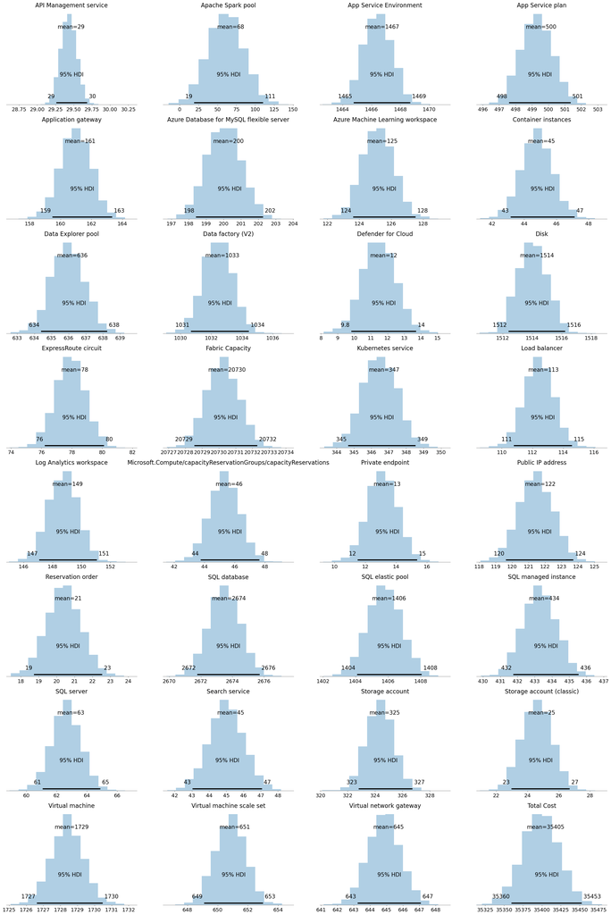

```python
ax = az.plot_posterior(trace, kind='hist', show=True, hdi_prob=.95)
```

The final Monte Carlo samples can be extracted from the “trace” variable (an arviz.InferenceData object) to be used for any downstream application or budget reporting.

Depending on the needs of your organization, these can be reported in any desired format, such as a web dashboard with the histograms above, and Excel report, or any other FinOps application.

Working with Inference Data: https://python.arviz.org/en/latest/getting_started/WorkingWithInferenceData.html#working-with-inferencedata

```python
trace
```

arviz.InferenceData

- posterior

  ```
  <xarray.Dataset>
  Dimensions:                                                           (
                                                                         chain: 4,
                                                                         draw: 1000)
  Coordinates:
    * chain                                                             (chain) int64 ...
    * draw                                                              (draw) int64 ...
  Data variables: (12/32)
      API Management service                                            (chain, draw) float64 ...
      Apache Spark pool                                                 (chain, draw) float64 ...
      App Service Environment                                           (chain, draw) float64 ...
      App Service plan                                                  (chain, draw) float64 ...
      Application gateway                                               (chain, draw) float64 ...
      Azure Database for MySQL flexible server                          (chain, draw) float64 ...
      ...                                                                ...
      Storage account                                                   (chain, draw) float64 ...
      Storage account (classic)                                         (chain, draw) float64 ...
      Virtual machine                                                   (chain, draw) float64 ...
      Virtual machine scale set                                         (chain, draw) float64 ...
      Virtual network gateway                                           (chain, draw) float64 ...
      Total Cost                                                        (chain, draw) float64 ...
  Attributes:
      created_at:                 2024-10-14T16:36:57.156808
      arviz_version:              0.17.1
      inference_library:          pymc
      inference_library_version:  5.16.1
      sampling_time:              40.21694207191467
      tuning_steps:               1000
  ```

- sample_stats

### Example Output

The simple example below shows how to extract the sampled values for Total Cost and calculated the expected budget value (mean), as well as the 99% percentile “worst-case” scenario.

```python
# Fold the the monte carlo chains into a single dimension and save the 'Total Cost' chain as a variable
total_cost_samples = az.extract(trace)['Total Cost']
```

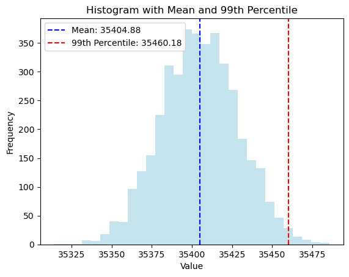

```python
# Calculate the mean and 99th percentile
mean_value = np.mean(total_cost_samples)
percentile_99 = np.percentile(total_cost_samples, 99)

# Plot the histogram
plt.hist(total_cost_samples, bins=30, alpha=0.7, color='lightblue')

# Add vertical lines for the mean and 99th percentile
plt.axvline(mean_value, color='b', linestyle='--', label=f'Mean: {mean_value:.2f}')
plt.axvline(percentile_99, color='r', linestyle='--', label=f'99th Percentile: {percentile_99:.2f}')

# Add labels and legend
plt.title('Histogram with Mean and 99th Percentile')
plt.xlabel('Value')
plt.ylabel('Frequency')
plt.legend()

# Show plot
plt.show()
```